# HW2_sj2921

Shan

2/14/2019

## Problem 1:

### Import data

```r
dose = c(0, 1, 2, 3, 4)
dying = c(2, 8, 15, 23, 27)
not_dying = 30 - dying
prob_die = dying/30
bio_df = data.frame(dose, dying, not_dying, prob_die)

## Look at the dataset
knitr::kable(bio_df,digits = 2)
```

| dose | dying | not_dying | prob_die |
| --- | --- | --- | --- |
| 0 | 2 | 28 | 0.07 |
| 1 | 8 | 22 | 0.27 |
| 2 | 15 | 15 | 0.50 |
| 3 | 23 | 7 | 0.77 |
| 4 | 27 | 3 | 0.90 |

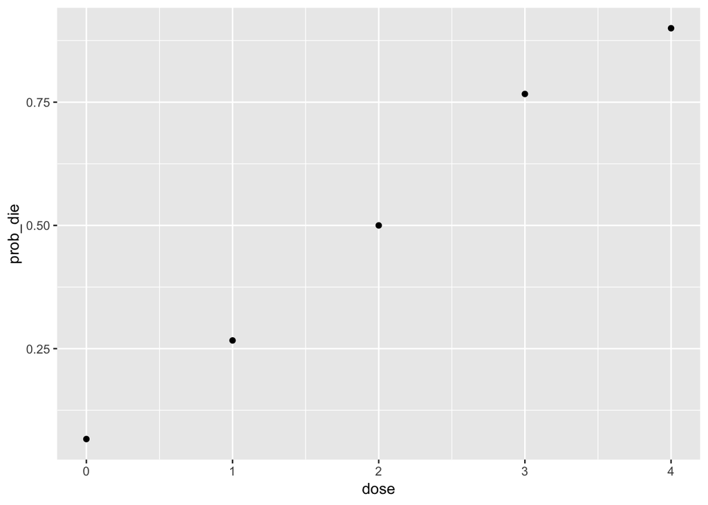

```r
ggplot(bio_df, aes(x = dose, y =  prob_die)) +
  geom_point()
```

#### Fit the GLM model

$$g (P(dying)) = \alpha + \beta X$$

#### Logit links

```r
y = cbind(dying, not_dying)
bio.logit = glm( y ~ dose,
                family = binomial(link = 'logit'), data = bio_df )
summary(bio.logit)
```

```
##
## Call:
## glm(formula = y ~ dose, family = binomial(link = "logit"), data = bio_df)
##
## Deviance Residuals:
##       1        2        3        4        5
## -0.4510   0.3597   0.0000   0.0643  -0.2045
##
## Coefficients:
##             Estimate Std. Error z value Pr(>|z|)
## (Intercept)  -2.3238     0.4179  -5.561 2.69e-08 ***
## dose          1.1619     0.1814   6.405 1.51e-10 ***
## ---
## Signif. codes:  0 '***' 0.001 '**' 0.01 '*' 0.05 '.' 0.1 ' ' 1
##
## (Dispersion parameter for binomial family taken to be 1)
##
##     Null deviance: 64.76327  on 4  degrees of freedom
## Residual deviance:  0.37875  on 3  degrees of freedom
## AIC: 20.854
##
## Number of Fisher Scoring iterations: 4
```

##### Confidence interval

```r
# CI for beta
vcov(bio.logit)
```

```
##             (Intercept)        dose
## (Intercept)  0.17463024 -0.06582336
## dose        -0.06582336  0.03291168
```

```r
# variance-covariance matrix of beta MLE (fisher information inverse)

beta = bio.logit$coefficients[2]
se = sqrt(vcov(bio.logit)[2,2]) # (same as in above)
beta + c(qnorm(0.025), 0, -qnorm(0.025)) * se
```

```
## [1] 0.8063266 1.1618949 1.5174633
```

##### deviance

```r
logit.dev = sum(residuals(bio.logit, type = 'deviance')^2)
logit.dev  ## Residual deviance:  0.37875
```

```
## [1] 0.3787483
```

The estimated regression is
$$log(\frac{\hat\pi(x)}{1-\hat\pi(x)}) = -2.3238 + 1.1619x$$
with $\beta_1$ being significant(p <0.01) and positive, implying that dose amount increases so does the probability of dying. As x increase 1 unit the odds of dying increase multiplicative by $e^{1.1619}=3.196$. That is, for a dose increase in concerntration, there is about a 219% increase in a chance of dying compared to a consuming 1 unit less dose(within the range of the data).

##### P(dying| x = 0.01)

```r
# CI for pi
predict(bio.logit,
        data.frame(dose = 0.01),
        se.fit = TRUE, type = 'response')$fit
```

```
##          1
## 0.09011997
```

#### probit link

```r
bio.probit = glm(cbind(dying,not_dying) ~ dose,
                family = binomial(link = probit ))
summary(bio.probit)
```

```
##
## Call:
## glm(formula = cbind(dying, not_dying) ~ dose, family = binomial(link = probit))
##
## Deviance Residuals:
##        1         2         3         4         5
## -0.35863   0.27493   0.01893   0.18230  -0.27545
##
## Coefficients:
##             Estimate Std. Error z value Pr(>|z|)
## (Intercept) -1.37709    0.22781  -6.045 1.49e-09 ***
## dose         0.68638    0.09677   7.093 1.31e-12 ***
## ---
## Signif. codes:  0 '***' 0.001 '**' 0.01 '*' 0.05 '.' 0.1 ' ' 1
##
## (Dispersion parameter for binomial family taken to be 1)
##
##     Null deviance: 64.76327  on 4  degrees of freedom
## Residual deviance:  0.31367  on 3  degrees of freedom
## AIC: 20.789
##
## Number of Fisher Scoring iterations: 4
```

##### Confidence interval

```r
# CI for beta
vcov(bio.probit)
```

```
##             (Intercept)         dose
## (Intercept)  0.05189588 -0.018760513
## dose        -0.01876051  0.009363749
```

```r
# variance-covariance matrix of beta MLE (fisher information inverse)
beta = bio.probit$coefficients[2]
se = sqrt(vcov(bio.probit)[2,2]) # (same as in above)
beta + c(qnorm(0.025), -qnorm(0.025)) * se # 0 is for point estimate
```

```
## [1] 0.4967217 0.8760393
```

##### deviance

```r
probit.dev = sum(residuals(bio.probit, type = 'deviance')^2)
probit.dev  ## Residual deviance:  0.3136684
```

```
## [1] 0.3136684
```

##### predict: hat

```r
# CI for pi
predict(bio.probit, data.frame(dose = 0.01),
        se.fit = TRUE, type = 'response')$fit
```

```
##         1
## 0.0853078
```

#### c-log-log link((complementary log-log))

```r
bio.log = glm(cbind(dying,not_dying) ~ dose,
                family = binomial(link = cloglog))
summary(bio.log)
```

```
##
## Call:
## glm(formula = cbind(dying, not_dying) ~ dose, family = binomial(link = cloglog))
##
## Deviance Residuals:
##       1        2        3        4        5
## -1.0831   0.2132   0.4985   0.5588  -0.6716
##
## Coefficients:
##             Estimate Std. Error z value Pr(>|z|)
## (Intercept)  -1.9942     0.3126  -6.378 1.79e-10 ***
## dose          0.7468     0.1094   6.824 8.86e-12 ***
## ---
## Signif. codes:  0 '***' 0.001 '**' 0.01 '*' 0.05 '.' 0.1 ' ' 1
##
## (Dispersion parameter for binomial family taken to be 1)
##
##     Null deviance: 64.7633  on 4  degrees of freedom
## Residual deviance:  2.2305  on 3  degrees of freedom
## AIC: 22.706
##
## Number of Fisher Scoring iterations: 5
```

##### Confidence interval

```r
# CI for beta
vcov(bio.log)
```

```
##             (Intercept)        dose
## (Intercept)  0.09774304 -0.03111671
## dose        -0.03111671  0.01197721
```

```r
# variance-covariance matrix of beta MLE (fisher information inverse)
beta = bio.log$coefficients[2]
se = sqrt(vcov(bio.log)[2,2]) # (same as in above)
beta + c(qnorm(0.025), 0, -qnorm(0.025)) * se # 0 is for point estimate
```

```
## [1] 0.5323200 0.7468193 0.9613187
```

##### deviance

```r
c_log.dev = sum(residuals(bio.log, type = 'deviance')^2)
c_log.dev  ## Residual deviance:  2.23048
```

```
## [1] 2.230479
```

##### predict: hat

```r
# CI for pi
predict(bio.log, data.frame(dose = 0.01), se.fit = TRUE, type = 'response')$fit
```

```
##         1
## 0.1281601
```

Fit a table

```r
row1 = c("model", "Estimateof beta" , "CI for beta", "Deviance", "p(dying|x = 0.01)")
row2 = c("logit",  1.1619, "[0.8063, 1.5175]", 0.3788, 0.0901)
row3 = c("probit",  0.6864,  "[0.4967 0.8761]" , 0.3137, 0.0853 )
row4 = c("c-log-log", 0.7468, "[0.5323, 0.9613]" ,2.2305, 0.1282)
p1 = rbind(row1, row2, row3, row4)
knitr::kable(p1,"latex")
```

[output not shown]

#### (ii). LD50 with 90% CI

##### (1)logit

```r
# LD50 est and CI
beta0 = bio.logit$coefficients[1]
beta1 = bio.logit$coefficients[2]
betacov = vcov(bio.logit) # inverse fisher information
x0fit = -beta0/beta1
x0fit # Used for cross validation
```

```
## (Intercept)
##           2
```

```r
exp(x0fit) # point estimate of LD50
```

```
## (Intercept)
##    7.389056
```

```r
varx0 = betacov[1,1]/(beta1^2) + betacov[2,2]*(beta0^2)/(beta1^4) -
  2*betacov[1,2]*beta0/(beta1^3)
c(x0fit,sqrt(varx0)) # point est and se
```

```
## (Intercept)        dose
##   2.0000000   0.1784367
```

```r
exp((x0fit + c(qnorm(0.05),-qnorm(0.05))*sqrt(varx0)))
```

```
## [1] 5.509631 9.909583
```

```r
# 90% CI for LD50
```

The 90% CI is (5.509631, 9.909583).

##### (2) probit

```r
# LD50 est and CI
beta0 = bio.probit$coefficients[1]
beta1 = bio.probit$coefficients[2]
betacov = vcov(bio.probit) # inverse fisher information
x0fit = -beta0/beta1
x0fit # Used for cross validation
```

```
## (Intercept)
##     2.00631
```

```r
exp(x0fit) # point estimate of LD50
```

```
## (Intercept)
##     7.43583
```

```r
varx0 = betacov[1,1]/(beta1^2) + betacov[2,2]*(beta0^2)/(beta1^4) -
  2*betacov[1,2]*beta0/(beta1^3)
c(x0fit,sqrt(varx0)) # point est and se
```

```
## (Intercept)        dose
##   2.0063102   0.1742755
```

```r
exp((x0fit + c(qnorm(0.05),-qnorm(0.05))*sqrt(varx0))) # 90% CI for LD50
```

```
## [1] 5.582588 9.904289
```

##### (3)c-log-clog

```r
# LD50 est and CI
beta0 = bio.log$coefficients[1]
beta1 = bio.log$coefficients[2]
betacov = vcov(bio.log) # inverse fisher information
x0fit = (log(log(2))-beta0)/beta1

x0fit # Used for cross validation
```

```
## (Intercept)
##    2.179428
```

```r
exp(x0fit) # point estimate of LD50
```

```
## (Intercept)
##    8.841249
```

```r
varx0 = betacov[1,1]/(beta1^2) + betacov[2,2]*((beta0- log(log(2)))^2)/(beta1^4) - 2* betacov[1,2] * (beta0 - log(log(2)))/(beta1^3)
c(x0fit,sqrt(varx0)) # point est and se
```

```
## (Intercept)        dose
##   2.1794281   0.1845721
```

```r
exp((x0fit + c(qnorm(0.05),-qnorm(0.05))*sqrt(varx0))) # 90% CI for LD50
```

```
## [1]  6.526261 11.977407
```

The estimate value for three links are as following:

- The logit function:
- LD50 point est. 7.389056; 90% CI [5.5096, 9.9096]
- The probit function:
- LD50 est. 7.436 ; 90% CI [5.583, 9.904]
- C-log-log function:
- LD50 point est. 8.841 ; 90% CI [6.5263, 11.9774]

### Problem 2

```r
## import data
amount = function(x)
    {x
    x * 5}

amount = amount(2:18)
offers = c(4, 6, 10, 12, 39, 36, 22, 14, 10, 12, 8, 9, 3, 1, 5, 2, 1)
enrolls =  c(0, 2, 4, 2, 12, 14, 10, 7, 5, 5, 3, 5, 2, 0, 4, 2, 1)
decline = offers - enrolls
mph_df = data.frame(amount,
                    offers,  decline, enrolls)

class(mph_df$amount)
```

```
## [1] "numeric"
```

```r
## Look at the dataset
knitr::kable(mph_df,digits = 2)
```

| amount | offers | decline | enrolls |
| --- | --- | --- | --- |
| 10 | 4 | 4 | 0 |
| 15 | 6 | 4 | 2 |
| 20 | 10 | 6 | 4 |
| 25 | 12 | 10 | 2 |
| 30 | 39 | 27 | 12 |
| 35 | 36 | 22 | 14 |
| 40 | 22 | 12 | 10 |
| 45 | 14 | 7 | 7 |
| 50 | 10 | 5 | 5 |
| 55 | 12 | 7 | 5 |
| 60 | 8 | 5 | 3 |
| 65 | 9 | 4 | 5 |
| 70 | 3 | 1 | 2 |
| 75 | 1 | 1 | 0 |
| 80 | 5 | 1 | 4 |
| 85 | 2 | 0 | 2 |
| 90 | 1 | 0 | 1 |

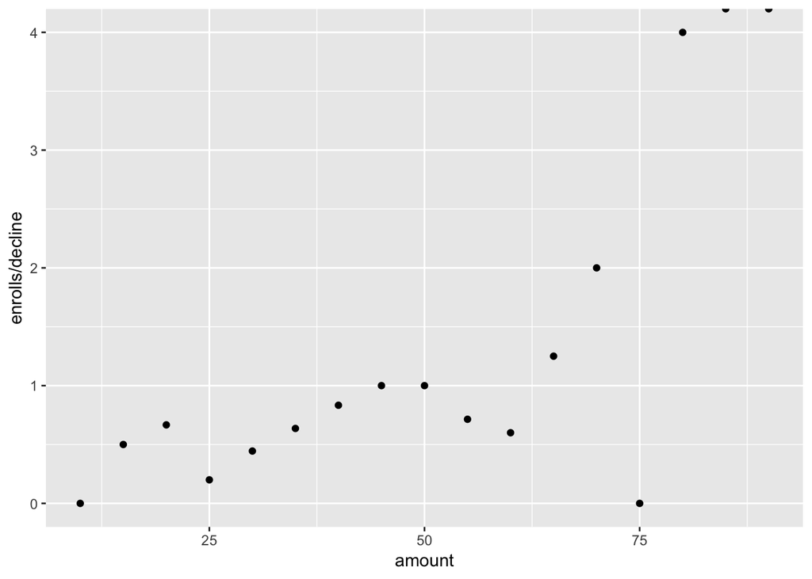

```r
ggplot(mph_df, aes(x = amount, y =  enrolls/decline)) +
  geom_point()
```

```r
## Fit the glm model
y = cbind(enrolls, decline)
mph.logit = glm( y ~ amount,
                family = binomial(link = 'logit'), data = mph_df )
summary(mph.logit)
```

```
##
## Call:
## glm(formula = y ~ amount, family = binomial(link = "logit"),
##     data = mph_df)
##
## Deviance Residuals:
##     Min       1Q   Median       3Q      Max
## -1.4735  -0.6731   0.1583   0.5285   1.1275
##
## Coefficients:
##             Estimate Std. Error z value Pr(>|z|)
## (Intercept) -1.64764    0.42144  -3.910 9.25e-05 ***
## amount       0.03095    0.00968   3.197  0.00139 **
## ---
## Signif. codes:  0 '***' 0.001 '**' 0.01 '*' 0.05 '.' 0.1 ' ' 1
##
## (Dispersion parameter for binomial family taken to be 1)
##
##     Null deviance: 21.617  on 16  degrees of freedom
## Residual deviance: 10.613  on 15  degrees of freedom
## AIC: 51.078
##
## Number of Fisher Scoring iterations: 4
```

##### 1. Goodness of fit

```r
##(1) Matched the grouped model fit

beta0 = coef(mph.logit)[1]
beta1 = coef(mph.logit)[2]
beta_0 = amount * beta1
pihat = fitted(mph.logit)

### Pearson-chi-square residual
G.res = ( y - offers  * pihat)/ sqrt ( offers * pihat *(1 - pihat))
residuals(mph.logit, type = "pearson")
```

```
##          1          2          3          4          5          6
## -1.0243724  0.5717600  0.9810994 -0.9711570 -0.2647020  0.3289076
##          7          8          9         10         11         12
##  0.5320014  0.4781082  0.1583651 -0.6722082 -1.0076450 -0.2103582
##         13         14         15         16         17
##  0.1424593 -1.4004895  0.5054964  0.8650220  0.5661196
```

```r
sum(residuals(mph.logit, type = "pearson")^2)
```

```
## [1] 8.814299
```

```r
## Deviance
dev = sum(residuals(mph.logit, type = "deviance")^2)
dev
```

```
## [1] 10.61271
```

```r
## compare with chi-square
pval = 1- pchisq(dev, 15) ## 2 parameters: 17-2 =15
## pval is 0.77 > 0.05, fail to reject the null hypothesis, our model fits well enough.
```

##### 2. Relationship between the scholarship amount and enrollment rate

```r
beta0
```

```
## (Intercept)
##   -1.647638
```

```r
beta1
```

```
##     amount
## 0.03095043
```

$$log(\frac{\pi}{1- \pi}) = amount \cdot \beta_1 + \beta_0$$
$$log(\frac{\pi}{1- \pi}) = amount \cdot 0.031 - 1.648$$
*Interpretation*: (1). In this study, we find that when there is no scholarship provided for mph students, log odds of enrollment would be -1.648; (2). For one thousand dollar increase of scholarship provided for mph students, the log odds of enrollment would increase by 0.031 keeping other factors the costant.

###### What is 95% CI?

```r
# CI for beta
vcov(mph.logit)
```

```
##              (Intercept)        amount
## (Intercept)  0.177611410 -3.809551e-03
## amount      -0.003809551  9.369767e-05
```

```r
# variance-covariance matrix of beta MLE (fisher information inverse)
beta = mph.logit$coefficients[2]
se = sqrt(vcov(mph.logit)[2,2]) # (same as in above)
beta + c(qnorm(0.025), 0, -qnorm(0.025)) * se # 0 is for point estimate
```

```
## [1] 0.01197845 0.03095043 0.04992240
```

```r
# CI for odds ratio: exp(beta); tranfer back.
exp(beta + c(qnorm(0.025),0,-qnorm(0.025)) * se)
```

```
## [1] 1.012050 1.031434 1.051190
```

The 95% CI for $\beta_1$ is [0.01198, 0.04992], we are 95% confident that the coefficient of amount falls between 0.01198 and 0.04992.

The 95% CI for odds ratio is [1.01205, 1.05119], we are 95% confident that the odds ratio of amount falls between 1.012050 and 1.051190, which is greater than 1, implying a positive correalation of scholarship and enrollment.

##### 3. Get 40% yield rate (the percentage of admitted students who enroll?) What is the 95% CI?

```r
# 40 yield rate est and CI
vcov(mph.logit) # inverse fisher information
```

```
##              (Intercept)        amount
## (Intercept)  0.177611410 -3.809551e-03
## amount      -0.003809551  9.369767e-05
```

```r
x_fit = (log(0.4/(1 - 0.4)) - beta0)/beta1  ## point est.  40.13429
beta1_sq = beta1^2
# point estimate of 40% yield rate
varx0 = betacov[1,1] *  (1/beta1)^2 + (log(2/3) - beta0)^2 *betacov[2,2] / (beta1^4) + 2 * ( betacov[1,2]  * (log(2/3) - beta0) * (1/beta1^3 ) )

c(x_fit,sqrt(varx0)) # point est and se
```

```
## (Intercept)      amount
##    40.13429   132.79449
```

```r
x_fit + c(qnorm(0.025),-qnorm(0.025))*sqrt(varx0) # 95% CI for yield rate 40%
```

```
## [1] -220.1381  300.4067
```